# Introduction to splines2

Wenjie Wang

2018-06-14

The package **splines2** is designed to be a supplementary package on splines. It provides functions constructing a variety of spline bases that are not available from the package **splines** shipped with **R**. Most functions have a very similar user interface with the function `bs` in package **splines**. Currently, **splines2** provides function constructing B-splines, integral of B-splines, monotone splines (M-splines) and its integral (I-splines), convex splines (C-splines), and their derivatives. Compared with package **splines**, **splines2** allows piecewise constant basis for B-splines. Also, it provides a more user-friendly function interface, more consistent handling on `NA`’s for spline derivatives.

In this vignette, we introduce the basic usage of the functions provided by examples. The details of function syntax are available in the package manual and thus will be not discussed.

An outline of the remainder of the vignette is as follows: We first introduce the functions constructing the monotone splines (M-splines), its integral (I-splines), and convex splines (C-splines). The `deriv` methods for derivatives is demonstrated at the same time. After then, toy examples for integral and derivative of B-splines and B-splines, M-splines allowing piecewise constant are given. Last but not the least, handy methods of S3 generic function predict for objects produced by **splines2** are demonstrated for the evaluation of the same spline basis at new values.

## M-splines using `mSpline`

M-splines (Ramsay 1988) can be considered as a normalized version of B-splines with unit integral within boundary knots. An example given by Ramsay (1988) was a quadratic M-splines with three internal knots placed at 0.3, 0.5, and 0.6. The boundary knots by default are the range of the data `x`, thus 0 and 1 in this example.

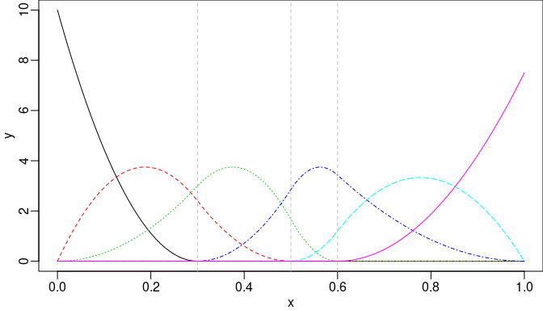

Quadratic M-splines with three internal knots.

```r
library(splines2)
knots <- c(0.3, 0.5, 0.6)
x <- seq(0, 1, 0.01)
msOut <- mSpline(x, knots = knots, degree = 2, intercept = TRUE)
library(graphics) # attach graphics (just in case) for plots
par(mar = c(2.5, 2.5, 0, 0), mgp = c(1.5, 0.5, 0))
matplot(x, msOut, type = "l", ylab = "y")
abline(v = knots, lty = 2, col = "gray") # mark internal knots
```

The derivative of given order of M-splines can be obtained by specifying a positive integer to argument `dervis` of `mSpline`. Also, for an existing `mSpline` object generated from function `mSpline`, the `deriv` method can be used conveniently. For example, the first derivative of the M-splines given in last example can be obtained equivalently as follows:

```r
dmsOut1 <- mSpline(x, knots = knots, degree = 2, intercept = TRUE, derivs = 1)
dmsOut2 <- deriv(msOut)
stopifnot(all.equal(dmsOut1, dmsOut2, check.attributes = FALSE))
```

## I-splines using `iSpline`

I-splines (Ramsay 1988) are simply the integral of M-splines and thus monotonically non-decreasing with unit maximum value. A monotonically non-decreasing (non-increasing) function can be fitted by a linear combination of I-spline bases with non-negative (non-positive) coefficients, plus a constant function (where the coefficient of the constant function is unconstrained).

The example given by Ramsay (1988) was the I-splines corresponding to that quadratic M-splines with three internal knots placed at 0.3, 0.5, and 0.6. Note that the degree of I-splines is defined from the associated M-splines instead of their own polynomial degree.

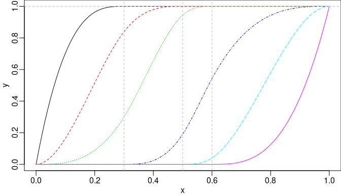

I-splines of degree two with three internal knots.

```r
isOut <- iSpline(x, knots = knots, degree = 2, intercept = TRUE)
par(mar = c(2.5, 2.5, 0, 0), mgp = c(1.5, 0.5, 0))
matplot(x, isOut, type = "l", ylab = "y")
abline(h = 1, v = knots, lty = 2, col = "gray")
```

The corresponding M-spline basis matrix can be obtained easily by the `deriv` method, which internally exacts the attribute named `msMat` in the object returned by function `iSpline`. In other words, if we need both M-spline bases and their integral splines in model fitting, `iSpline` and its `deriv` method should be used, while an extra function call of `mSpline` should be avoided for a better performance.

```r
stopifnot(all.equal(msOut, deriv(isOut)))
```

## C-splines using `cSpline`

Convex splines (Meyer 2008) called C-splines are a scaled version of I-splines’ integral with unit maximum value. Meyer (2008) applied C-splines to shape-restricted regression analysis. The monotone property of I-spines ensures the convexity of C-splines. A convex regression function can be estimated using linear combinations of the C-spline bases with non-negative coefficients, plus an unrestricted linear combination of the constant function and the identity function $g(x)=x$. If the underlying regression function is both increasing and convex, the coefficient on the identity function is restricted to be nonnegative as well.

Function `cSpline` provides argument `scale` specifying whether scaling on C-spline bases is required. If `scale = TRUE` (by default), each C-spline basis is scaled to have unit height at right boundary knot. For its first (second) derivative, the `deriv` method can be used, which internally exacts the corresponding I-spline (M-spline) bases shipped in attributes `isMat` (`msMat`) scaled to the same extent. The derivatives of higher order can be obtained by specifying argument `derivs` in the `deriv` method.

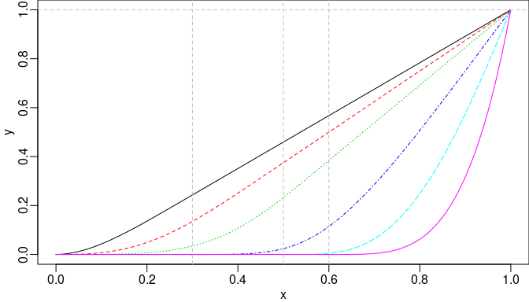

C-splines of degree two with three internal knots.

```r
csOut1 <- cSpline(x, knots = knots, degree = 2, intercept = TRUE)
par(mar = c(2.5, 2.5, 0, 0), mgp = c(1.5, 0.5, 0))
matplot(x, csOut1, type = "l", ylab = "y")
abline(h = 1, v = knots, lty = 2, col = "gray")
```

If `scale = FALSE`, the actual integral of I-spline basis will be returned. Similarly, the corresponding `deriv` method is provided. For derivatives of order greater than one, the nested call of `deriv` is supported. However, argument `derivs` can be specified if possible for a better performance. For example, the first and second derivatives can be obtained by the following equivalent approaches, respectively.

```r
csOut2 <- cSpline(x, knots = knots, degree = 2, intercept = TRUE, scale = FALSE)
stopifnot(all.equal(isOut, deriv(csOut2), check.attributes = FALSE))
stopifnot(all.equal(msOut, deriv(csOut2, 2), deriv(deriv(csOut2)),
                    check.attributes = FALSE))
```

## Integral and derivative of B-splines using `ibs` and `dbs`

A close-form recursive formulas of B-spline integral and derivative given by De Boor (1978) are implemented. Two toy example are given as follows:

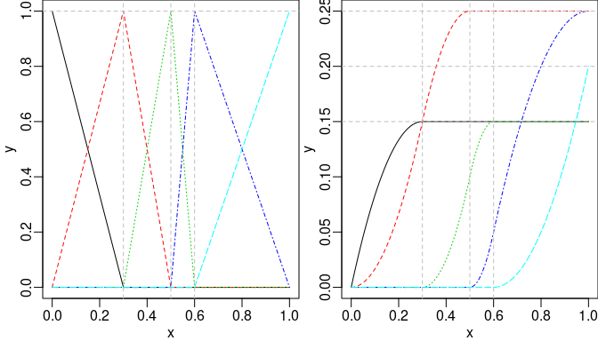

Piecewise linear B-splines (left) and their integrals (right).

```r
ibsOut <- ibs(x, knots = knots, degree = 1, intercept = TRUE)
par(mar = c(2.5, 2.5, 0, 0), mgp = c(1.5, 0.5, 0), mfrow = c(1, 2))
matplot(x, deriv(ibsOut), type = "l", ylab = "y")
abline(v = knots, h = 1, lty = 2, col = "gray")
matplot(x, ibsOut, type = "l", ylab = "y")
abline(v = knots, h = c(0.15, 0.2, 0.25), lty = 2, col = "gray")
```

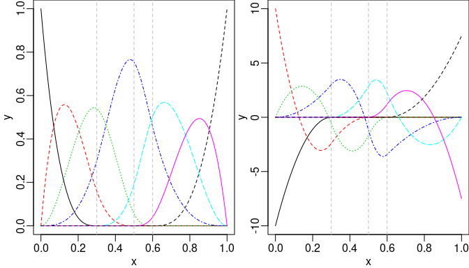

Cubic B-splines (left) and their first derivative (right).

```r
dbsOut <- dbs(x, knots = knots, intercept = TRUE)
bsOut <- bSpline(x, knots = knots, intercept = TRUE)
par(mar = c(2.5, 2.5, 0, 0), mgp = c(1.5, 0.5, 0), mfrow = c(1, 2))
matplot(x, bsOut, type = "l", ylab = "y")
abline(v = knots, lty = 2, col = "gray")
matplot(x, dbsOut, type = "l", ylab = "y")
abline(v = knots, lty = 2, col = "gray")
```

## B-splines using `bSpline`

Function `bSpline` provides B-spline bases and allows `degree = 0` for piecewise constant bases, which is one simple but handy extension to function `bs` in package **splines**. (For positive `degree`, `bSpline` internally call `bs` to do the hard work.) Step function or piecewise constant bases (close on the left and open on the right) are often used in practice for a reasonable approximation without any assumption on the form of target function. One simple example of B-splines and M-splines of degree zero is given as follows:

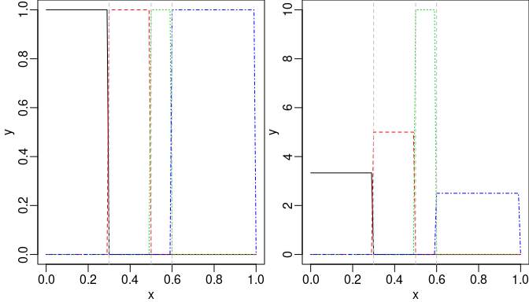

B-splines (left) and M-splines (right) of degree zero

```r
bsOut0 <- bSpline(x, knots = knots, degree = 0, intercept = TRUE)
msOut0 <- mSpline(x, knots = knots, degree = 0, intercept = TRUE)
par(mar = c(2.5, 2.5, 0, 0), mgp = c(1.5, 0.5, 0), mfrow = c(1, 2))
matplot(x, bsOut0, type = "l", ylab = "y")
abline(v = knots, lty = 2, col = "gray")
matplot(x, msOut0, type = "l", ylab = "y")
abline(v = knots, lty = 2, col = "gray")
```

## Evaluation on New Values by `predict`

The methods for **splines2** objects dispatched by generic function `predict` are useful if we want to evaluate the spline object at possibly new $x$ values. For instance, if we want to evaluate the value of I-splines object in previous example at 0.275, 0.525, and 0.8, respectively, all we need is

```r
predict(isOut, c(0.275, 0.525, 0.8))
```

```
##              1         2         3         4        5     6
## [1,] 0.9994213 0.7730556 0.2310764 0.0000000 0.000000 0.000
## [2,] 1.0000000 1.0000000 0.9765625 0.2696429 0.000625 0.000
## [3,] 1.0000000 1.0000000 1.0000000 0.9428571 0.580000 0.125
```

Technically speaking, the methods take all information needed, such as `knots`, `degree`, `intercept`, etc., from attributes of the original **splines2** objects and call the corresponding function automatically for those new $x$ values. Therefore, the `predict` methods will not be applicable if those attributes are somehow lost after certain operation.

## Reference

De Boor, Carl. 1978. *A Practical Guide to Splines*. Vol. 27. New York: springer-verlag. https://doi.org/10.1002/zamm.19800600129.

Meyer, Mary C. 2008. “Inference Using Shape-Restricted Regression Splines.” *The Annals of Applied Statistics*. JSTOR, 1013–33. https://doi.org/10.1214/08-AOAS167.

Ramsay, J O. 1988. “Monotone Regression Splines in Action.” *Statistical Science*. JSTOR, 425–41. https://doi.org/10.1214/ss/1177012761.